# HW4_Jie He

# Q6

# a

```r
Y = -6 + 0.05*40 + 1*3.5
PX = exp(Y)/(1+exp(Y))
PX
```

```
## [1] 0.3775407
```

```r
exp(-6+0.05*40+1*3.5)/(1+exp(-6+0.05*40+1*3.5))
```

```
## [1] 0.3775407
```

The probability is 0.3775407.

# b

```r
(log(1)+6-1*3.5)/0.05
```

```
## [1] 50
```

50 hours are needed.

# Q13(logistic only)

```r
#load library and data
library(MASS)
data(Boston)
summary(Boston)
```

```
##       crim                zn             indus            chas
##  Min.   : 0.00632   Min.   :  0.00   Min.   : 0.46   Min.   :0.00000
##  1st Qu.: 0.08204   1st Qu.:  0.00   1st Qu.: 5.19   1st Qu.:0.00000
##  Median : 0.25651   Median :  0.00   Median : 9.69   Median :0.00000
##  Mean   : 3.61352   Mean   : 11.36   Mean   :11.14   Mean   :0.06917
##  3rd Qu.: 3.67708   3rd Qu.: 12.50   3rd Qu.:18.10   3rd Qu.:0.00000
##  Max.   :88.97620   Max.   :100.00   Max.   :27.74   Max.   :1.00000
##       nox               rm             age              dis
##  Min.   :0.3850   Min.   :3.561   Min.   :  2.90   Min.   : 1.130
##  1st Qu.:0.4490   1st Qu.:5.886   1st Qu.: 45.02   1st Qu.: 2.100
##  Median :0.5380   Median :6.208   Median : 77.50   Median : 3.207
##  Mean   :0.5547   Mean   :6.285   Mean   : 68.57   Mean   : 3.795
##  3rd Qu.:0.6240   3rd Qu.:6.623   3rd Qu.: 94.08   3rd Qu.: 5.188
##  Max.   :0.8710   Max.   :8.780   Max.   :100.00   Max.   :12.127
##       rad              tax           ptratio          black
##  Min.   : 1.000   Min.   :187.0   Min.   :12.60   Min.   :  0.32
##  1st Qu.: 4.000   1st Qu.:279.0   1st Qu.:17.40   1st Qu.:375.38
##  Median : 5.000   Median :330.0   Median :19.05   Median :391.44
##  Mean   : 9.549   Mean   :408.2   Mean   :18.46   Mean   :356.67
##  3rd Qu.:24.000   3rd Qu.:666.0   3rd Qu.:20.20   3rd Qu.:396.23
##  Max.   :24.000   Max.   :711.0   Max.   :22.00   Max.   :396.90
##      lstat            medv
##  Min.   : 1.73   Min.   : 5.00
##  1st Qu.: 6.95   1st Qu.:17.02
##  Median :11.36   Median :21.20
##  Mean   :12.65   Mean   :22.53
##  3rd Qu.:16.95   3rd Qu.:25.00
##  Max.   :37.97   Max.   :50.00
```

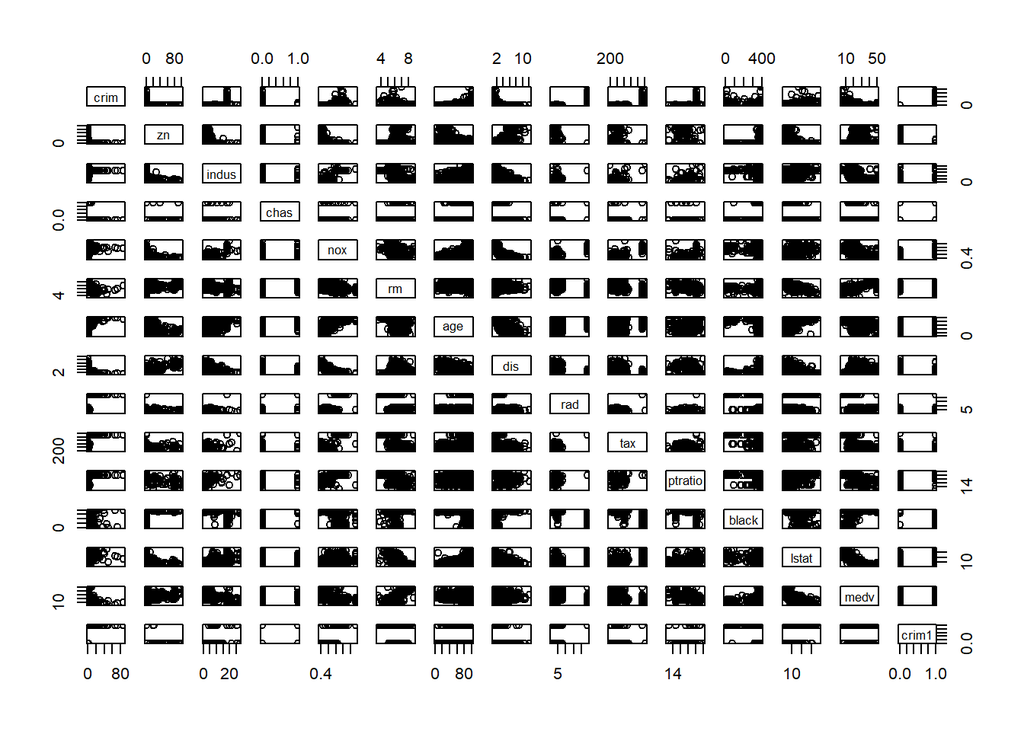

```r
#create a class variable in a data frame
crim1 <- ifelse(Boston$crim > median(Boston$crim), 1, 0)
myDF1 <- data.frame(Boston, crim1)
pairs(myDF1)
```

```r
sort(cor(myDF1)[1,])
```

```
##        medv       black         dis          rm          zn        chas
## -0.38830461 -0.38506394 -0.37967009 -0.21924670 -0.20046922 -0.05589158
##     ptratio         age       indus       crim1         nox       lstat
##  0.28994558  0.35273425  0.40658341  0.40939545  0.42097171  0.45562148
##         tax         rad        crim
##  0.58276431  0.62550515  1.00000000
```

```r
#train the model
set.seed(1)
#sampling without replacement for training data
train_1 <- sample(1:nrow(myDF1), nrow(myDF1)*0.7, replace = F)
train <- myDF1[train_1,]
test <- myDF1[-train_1,]
#splitting variables/using subsets of the predictors
train.X1 <- cbind(train$age, train$dis, train$lstat, train$medv)
test.X1 <- cbind(test$age, test$dis, test$lstat, test$medv)
train.X2 <- cbind(train$tax, train$rad)
test.X2 <- cbind(test$tax, test$rad)
#Do Logistic Regression
fit.logit_1 <- glm(crim1~age+dis+lstat+medv, data=train, family=binomial)
summary(fit.logit_1)
```

```
##
## Call:
## glm(formula = crim1 ~ age + dis + lstat + medv, family = binomial,
##     data = train)
##
## Deviance Residuals:
##     Min       1Q   Median       3Q      Max
## -2.2991  -0.5439   0.1064   0.6426   2.8623
##
## Coefficients:
##              Estimate Std. Error z value Pr(>|z|)
## (Intercept) -0.691113   1.352797  -0.511 0.609437
## age          0.033036   0.009238   3.576 0.000349 ***
## dis         -0.598575   0.132517  -4.517 6.27e-06 ***
## lstat        0.038312   0.038361   0.999 0.317923
## medv        -0.002906   0.023758  -0.122 0.902653
## ---
## Signif. codes:  0 '***' 0.001 '**' 0.01 '*' 0.05 '.' 0.1 ' ' 1
##
## (Dispersion parameter for binomial family taken to be 1)
##
##     Null deviance: 490.75  on 353  degrees of freedom
## Residual deviance: 300.06  on 349  degrees of freedom
## AIC: 310.06
##
## Number of Fisher Scoring iterations: 5
```

```r
logit_1.prob <- predict(fit.logit_1, test, type="response")
logit_1.pred <- ifelse(logit_1.prob>0.5, 1, 0)
#test error rate
mean(logit_1.pred != test$crim1)
```

```
## [1] 0.1644737
```

```r
#make a confusion matrix
table(test$crim1, logit_1.prob>0.5)
```

```
##
##     FALSE TRUE
##   0    62   14
##   1    11   65
```

```r
fit.logit_2 <- glm(crim1~tax+rad, data=train, family=binomial)
summary(fit.logit_2)
```

```
##
## Call:
## glm(formula = crim1 ~ tax + rad, family = binomial, data = train)
##
## Deviance Residuals:
##     Min       1Q   Median       3Q      Max
## -1.4267  -0.8179  -0.2039   0.0697   2.0795
##
## Coefficients:
##              Estimate Std. Error z value Pr(>|z|)
## (Intercept) -3.338254   0.601167  -5.553 2.81e-08 ***
## tax          0.003913   0.001721   2.274 0.022959 *
## rad          0.281293   0.072911   3.858 0.000114 ***
## ---
## Signif. codes:  0 '***' 0.001 '**' 0.01 '*' 0.05 '.' 0.1 ' ' 1
##
## (Dispersion parameter for binomial family taken to be 1)
##
##     Null deviance: 490.75  on 353  degrees of freedom
## Residual deviance: 307.72  on 351  degrees of freedom
## AIC: 313.72
##
## Number of Fisher Scoring iterations: 7
```

```r
logit_2.prob <- predict(fit.logit_2, test, type="response")
logit_2.pred <- ifelse(logit_2.prob>0.5, 1, 0)
#test error rate
mean(logit_2.pred != test$crim1)
```

```
## [1] 0.2434211
```

```r
#make a confusion matrix
table(test$crim1, logit_2.prob>0.5)
```

```
##
##     FALSE TRUE
##   0    71    5
##   1    32   44
```

For the first model, I used age, dis, lstat, and medv to predict crim1. It seems that age and dis are both significant because of their p-values but lstat and medv are not. The test error rate is 0.1644737. Based on the confusion matrix, the rate of misclassification is
$$25/152=0.1644737$$
and the accuracy rate is
$$127/152=0.8355263$$
For the second model, I used tax and rad to predict crim1. It seems that both predictors are significant because of their p-values. The test error rate is 0.2434211. Based on the confusion matrix, the rate of misclassification is
$$37/152=0.2434211$$
and the accuracy rate is
$$115/152=0.7565789$$

# Image Classification

```r
#load the data set into a data frame
load("mnist_all.RData")
mydf <- data.frame(train)

#define a plot function for the training data
plot_digit <- function(j){
  arr784 <- as.numeric(train$x[j,])
  col=gray(12:1/12)
  image(matrix(arr784, nrow=28)[,28:1], col=col,
        main = paste("this is a ",train$y[j]))
}

#remove rows other than 0 and 1
myData <- mydf[mydf$y <= 1,]
```

# P1

```r
#features are pixel values
#myfeatures_col = sample(784,1)
myfeatures_col = 276
myDataFrame <- myData[,c(myfeatures_col,786)]
myDataFrame$labels = as.numeric(myData$y==0)

#logistic regression
fit.lm_1 <- glm(labels ~ myDataFrame[,1], data = myDataFrame, family = binomial)
summary(fit.lm_1)
```

```
##
## Call:
## glm(formula = labels ~ myDataFrame[, 1], family = binomial, data = myDataFrame)
##
## Deviance Residuals:
##     Min       1Q   Median       3Q      Max
## -5.0437  -0.8309  -0.8309   0.3162   1.5693
##
## Coefficients:
##                   Estimate Std. Error z value Pr(>|z|)
## (Intercept)      -0.886117   0.022661  -39.10   <2e-16 ***
## myDataFrame[, 1]  0.053565   0.002456   21.81   <2e-16 ***
## ---
## Signif. codes:  0 '***' 0.001 '**' 0.01 '*' 0.05 '.' 0.1 ' ' 1
##
## (Dispersion parameter for binomial family taken to be 1)
##
##     Null deviance: 17504  on 12664  degrees of freedom
## Residual deviance: 11898  on 12663  degrees of freedom
## AIC: 11902
##
## Number of Fisher Scoring iterations: 8
```

```r
fit.lm_1.predict <- predict(fit.lm_1, type = "response")
table(myDataFrame$labels, fit.lm_1.predict>0.5) #threshold 0.5
```

```
##
##     FALSE TRUE
##   0  6696   46
##   1  2681 3242
```

# P2

```r
#pick up two variables with small correlation
#myfeatures_col_1 = sort(sample(784,2))
myfeatures_col_1 = c(322,580)
cor(myData[,myfeatures_col_1[1]],myData[,myfeatures_col_1[2]])
```

```
## [1] 0.15623
```

```r
myDF <- myData[,c(myfeatures_col_1,786)]
myDF$labels = as.numeric(myData$y==0)

#logistic regression
fit.lm_2 <- glm(labels ~ myDF[,1] + myDF[,2], data = myDF, family = binomial)
summary(fit.lm_2)
```

```
##
## Call:
## glm(formula = labels ~ myDF[, 1] + myDF[, 2], family = binomial,
##     data = myDF)
##
## Deviance Residuals:
##     Min       1Q   Median       3Q      Max
## -3.7586  -0.4698  -0.4698   0.2211   2.1254
##
## Coefficients:
##               Estimate Std. Error z value Pr(>|z|)
## (Intercept) -2.1483026  0.0390918  -54.95   <2e-16 ***
## myDF[, 1]    0.0114465  0.0002739   41.79   <2e-16 ***
## myDF[, 2]    0.0246745  0.0005376   45.89   <2e-16 ***
## ---
## Signif. codes:  0 '***' 0.001 '**' 0.01 '*' 0.05 '.' 0.1 ' ' 1
##
## (Dispersion parameter for binomial family taken to be 1)
##
##     Null deviance: 17504.4  on 12664  degrees of freedom
## Residual deviance:  8331.3  on 12662  degrees of freedom
## AIC: 8337.3
##
## Number of Fisher Scoring iterations: 6
```

```r
fit.lm_2.predict <- predict(fit.lm_2, type = "response")
table(myDF$labels, fit.lm_2.predict>0.5)
```

```
##
##     FALSE TRUE
##   0  6160  582
##   1   893 5030
```

```r
#calculate AUC
library(pROC)
roc <- roc(myDF$labels,fit.lm_2.predict)
auc(roc)
```

```
## Area under the curve: 0.9386
```

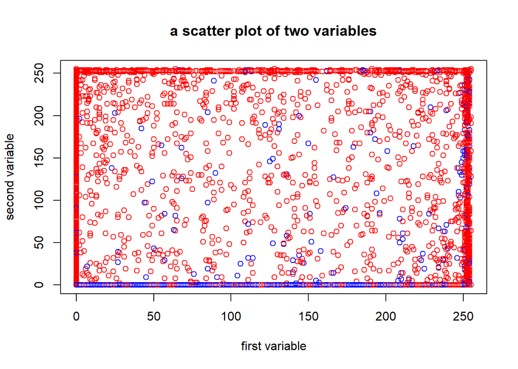

```r
#make a scatter plot
plot(myDF[,1], myDF[,2], col=ifelse(myDF$labels==0, "blue", "red"), main="a scatter plot of two variables", xlab = "first variable", ylab = "second variable")
legend(0, 350, pch=c(1,1), col=c("blue", "red"), c("0", "1"), cex=0.8)
```

# P3

```r
#find 10 variables with the largest variances
sort(apply(myData,2,var))
```

[output not shown]

[output cut: 261 more lines]

```
## 1.257349e+04 1.259102e+04 1.266493e+04 1.266571e+04 1.267608e+04
##        x.632        x.183        x.571        x.244        x.597
## 1.268628e+04 1.269878e+04 1.273312e+04 1.273654e+04 1.277317e+04
##        x.570        x.518        x.216        x.187        x.243
## 1.282577e+04 1.286301e+04 1.288291e+04 1.289957e+04 1.293960e+04
##        x.210        x.576        x.238        x.599        x.491
## 1.293990e+04 1.294640e+04 1.297797e+04 1.299179e+04 1.301062e+04
##        x.215        x.627        x.604        x.626        x.598
## 1.303208e+04 1.303376e+04 1.304076e+04 1.312494e+04 1.335197e+04
##        x.324        x.434        x.490        x.380        x.351
## 1.339294e+04 1.354113e+04 1.365183e+04 1.366489e+04 1.367039e+04
##        x.352        x.462        x.463        x.379        x.435
## 1.395382e+04 1.400845e+04 1.422423e+04 1.490205e+04 1.516362e+04
##        x.407
## 1.540778e+04
```

```r
myFrame <- myData[,c(408,436,380,464,463,353,352,381,491,435,786)]
myFrame$labels = as.numeric(myData$y==0)

#logistic regression
fit.lm_3 <- glm(labels ~ myFrame[,1] + myFrame[,2] + myFrame[,3] + myFrame[,4] + myFrame[,5] + myFrame[,6] + myFrame[,7] + myFrame[,8] + myFrame[,9] + myFrame[,10], data = myFrame, family = binomial)
summary(fit.lm_3)
```

```
##
## Call:
## glm(formula = labels ~ myFrame[, 1] + myFrame[, 2] + myFrame[,
##     3] + myFrame[, 4] + myFrame[, 5] + myFrame[, 6] + myFrame[,
##     7] + myFrame[, 8] + myFrame[, 9] + myFrame[, 10], family = binomial,
##     data = myFrame)
##
## Deviance Residuals:
##     Min       1Q   Median       3Q      Max
## -3.2821  -0.0535  -0.0320   0.0958   3.9196
##
## Coefficients:
##                Estimate Std. Error z value Pr(>|z|)
## (Intercept)    5.381427   0.173351  31.043  < 2e-16 ***
## myFrame[, 1]  -0.005319   0.002554  -2.083 0.037295 *
## myFrame[, 2]  -0.006364   0.002467  -2.579 0.009904 **
## myFrame[, 3]  -0.002766   0.002561  -1.080 0.280096
## myFrame[, 4]  -0.011875   0.001722  -6.898 5.27e-12 ***
## myFrame[, 5]  -0.006390   0.002615  -2.444 0.014531 *
## myFrame[, 6]  -0.001963   0.001781  -1.102 0.270501
## myFrame[, 7]  -0.002624   0.001865  -1.407 0.159352
## myFrame[, 8]  -0.008275   0.001852  -4.468 7.90e-06 ***
## myFrame[, 9]   0.001590   0.001871   0.850 0.395532
## myFrame[, 10] -0.007240   0.001893  -3.823 0.000132 ***
## ---
## Signif. codes:  0 '***' 0.001 '**' 0.01 '*' 0.05 '.' 0.1 ' ' 1
##
## (Dispersion parameter for binomial family taken to be 1)
##
##     Null deviance: 17504.4  on 12664  degrees of freedom
## Residual deviance:  1130.5  on 12654  degrees of freedom
## AIC: 1152.5
##
## Number of Fisher Scoring iterations: 8
```

```r
fit.lm_3.predict <- predict(fit.lm_3, type = "response")
table(myFrame$labels, fit.lm_3.predict>0.5)
```

```
##
##     FALSE TRUE
##   0  6665   77
##   1    84 5839
```

```r
#create a ROC curve
library(pROC)
roc_1 <- roc(myFrame$labels,fit.lm_3.predict)
auc(roc_1)
```

```
## Area under the curve: 0.9977
```

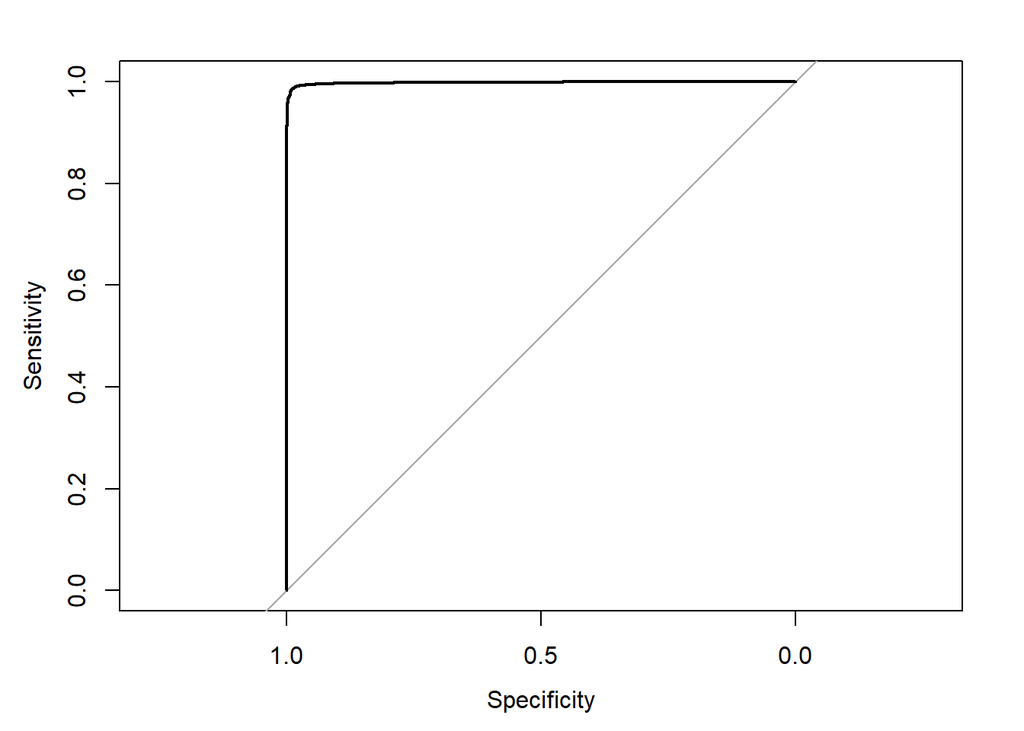

```r
plot(roc_1)
```

I built a classifier using the 10 variables with the largest variances. AUC is 0.9977 which indicates that the model is nearly perfect.